# sklearn.linear_model.RidgeCV

**class*sklearn.linear_model.RidgeCV(*alphas=(0.1, 1.0, 10.0)*, *, *fit_intercept=True*, *normalize='deprecated'*, *scoring=None*, *cv=None*, *gcv_mode=None*, *store_cv_values=False*, *alpha_per_target=False*)[[source]](https://github.com/scikit-learn/scikit-learn/blob/f3f51f9b6/sklearn/linear_model/_ridge.py#L2207)**

Ridge regression with built-in cross-validation.

See glossary entry for [cross-validation estimator](https://scikit-learn.org/1.1/glossary.html#term-cross-validation-estimator).

By default, it performs efficient Leave-One-Out Cross-Validation.

Read more in the User Guide.

**Parameters:**

**alphas**ndarray of shape (n_alphas,), default=(0.1, 1.0, 10.0)**

Array of alpha values to try. Regularization strength; must be a positive float. Regularization improves the conditioning of the problem and reduces the variance of the estimates. Larger values specify stronger regularization. Alpha corresponds to `1 / (2C)` in other linear models such as `LogisticRegression` or `LinearSVC`. If using Leave-One-Out cross-validation, alphas must be positive.

**fit_intercept**bool, default=True**

Whether to calculate the intercept for this model. If set to false, no intercept will be used in calculations (i.e. data is expected to be centered).

**normalize**bool, default=False**

This parameter is ignored when `fit_intercept` is set to False. If True, the regressors X will be normalized before regression by subtracting the mean and dividing by the l2-norm. If you wish to standardize, please use `StandardScaler` before calling `fit` on an estimator with `normalize=False`.

Deprecated since version 1.0: `normalize` was deprecated in version 1.0 and will be removed in 1.2.

**scoring**str, callable, default=None**

A string (see model evaluation documentation) or a scorer callable object / function with signature `scorer(estimator, X, y)`. If None, the negative mean squared error if cv is ‘auto’ or None (i.e. when using leave-one-out cross-validation), and r2 score otherwise.

**cv**int, cross-validation generator or an iterable, default=None**

Determines the cross-validation splitting strategy. Possible inputs for cv are:

- None, to use the efficient Leave-One-Out cross-validation
- integer, to specify the number of folds.
- [CV splitter](https://scikit-learn.org/1.1/glossary.html#term-CV-splitter),
- An iterable yielding (train, test) splits as arrays of indices.

For integer/None inputs, if `y` is binary or multiclass, `StratifiedKFold` is used, else, `KFold` is used.

Refer User Guide for the various cross-validation strategies that can be used here.

**gcv_mode**{‘auto’, ‘svd’, ‘eigen’}, default=’auto’**

Flag indicating which strategy to use when performing Leave-One-Out Cross-Validation. Options are:

```
'auto' : use 'svd' if n_samples > n_features, otherwise use 'eigen'
'svd' : force use of singular value decomposition of X when X is
    dense, eigenvalue decomposition of X^T.X when X is sparse.
'eigen' : force computation via eigendecomposition of X.X^T
```

The ‘auto’ mode is the default and is intended to pick the cheaper option of the two depending on the shape of the training data.

**store_cv_values**bool, default=False**

Flag indicating if the cross-validation values corresponding to each alpha should be stored in the `cv_values_` attribute (see below). This flag is only compatible with `cv=None` (i.e. using Leave-One-Out Cross-Validation).

**alpha_per_target**bool, default=False**

Flag indicating whether to optimize the alpha value (picked from the `alphas` parameter list) for each target separately (for multi-output settings: multiple prediction targets). When set to `True`, after fitting, the `alpha_` attribute will contain a value for each target. When set to `False`, a single alpha is used for all targets.

New in version 0.24.

**Attributes:**

**cv_values_**ndarray of shape (n_samples, n_alphas) or shape (n_samples, n_targets, n_alphas), optional**

Cross-validation values for each alpha (only available if `store_cv_values=True` and `cv=None`). After `fit()` has been called, this attribute will contain the mean squared errors if `scoring is None` otherwise it will contain standardized per point prediction values.

**coef_**ndarray of shape (n_features) or (n_targets, n_features)**

Weight vector(s).

**intercept_**float or ndarray of shape (n_targets,)**

Independent term in decision function. Set to 0.0 if `fit_intercept = False`.

**alpha_**float or ndarray of shape (n_targets,)**

Estimated regularization parameter, or, if `alpha_per_target=True`, the estimated regularization parameter for each target.

**best_score_**float or ndarray of shape (n_targets,)**

Score of base estimator with best alpha, or, if `alpha_per_target=True`, a score for each target.

New in version 0.23.

**n_features_in_**int**

Number of features seen during fit.

New in version 0.24.

**feature_names_in_**ndarray of shape (`n_features_in_`,)**

Names of features seen during fit. Defined only when `X` has feature names that are all strings.

New in version 1.0.

See also

**`Ridge`**

Ridge regression.

**`RidgeClassifier`**

Classifier based on ridge regression on {-1, 1} labels.

**`RidgeClassifierCV`**

Ridge classifier with built-in cross validation.

#### Examples

```
>>> from sklearn.datasets import load_diabetes
>>> from sklearn.linear_model import RidgeCV
>>> X, y = load_diabetes(return_X_y=True)
>>> clf = RidgeCV(alphas=[1e-3, 1e-2, 1e-1, 1]).fit(X, y)
>>> clf.score(X, y)
0.5166...
```

#### Methods

| `fit`(X, y[, sample_weight]) | Fit Ridge regression model with cv. |
| --- | --- |
| `get_params`([deep]) | Get parameters for this estimator. |
| `predict`(X) | Predict using the linear model. |
| `score`(X, y[, sample_weight]) | Return the coefficient of determination of the prediction. |
| `set_params`(**params) | Set the parameters of this estimator. |

**fit(*X*, *y*, *sample_weight=None*)[[source]](https://github.com/scikit-learn/scikit-learn/blob/f3f51f9b6/sklearn/linear_model/_ridge.py#L2107)**

Fit Ridge regression model with cv.

**Parameters:**

**X**ndarray of shape (n_samples, n_features)**

Training data. If using GCV, will be cast to float64 if necessary.

**y**ndarray of shape (n_samples,) or (n_samples, n_targets)**

Target values. Will be cast to X’s dtype if necessary.

**sample_weight**float or ndarray of shape (n_samples,), default=None**

Individual weights for each sample. If given a float, every sample will have the same weight.

**Returns:**

**self**object**

Fitted estimator.

#### Notes

When sample_weight is provided, the selected hyperparameter may depend on whether we use leave-one-out cross-validation (cv=None or cv=’auto’) or another form of cross-validation, because only leave-one-out cross-validation takes the sample weights into account when computing the validation score.

**get_params(*deep=True*)[[source]](https://github.com/scikit-learn/scikit-learn/blob/f3f51f9b6/sklearn/base.py#L194)**

Get parameters for this estimator.

**Parameters:**

**deep**bool, default=True**

If True, will return the parameters for this estimator and contained subobjects that are estimators.

**Returns:**

**params**dict**

Parameter names mapped to their values.

**predict(*X*)[[source]](https://github.com/scikit-learn/scikit-learn/blob/f3f51f9b6/sklearn/linear_model/_base.py#L372)**

Predict using the linear model.

**Parameters:**

**X**array-like or sparse matrix, shape (n_samples, n_features)**

Samples.

**Returns:**

**C**array, shape (n_samples,)**

Returns predicted values.

**score(*X*, *y*, *sample_weight=None*)[[source]](https://github.com/scikit-learn/scikit-learn/blob/f3f51f9b6/sklearn/base.py#L677)**

Return the coefficient of determination of the prediction.

The coefficient of determination $R^2$ is defined as $(1 - \frac{u}{v})$, where $u$ is the residual sum of squares `((y_true - y_pred)** 2).sum()` and $v$ is the total sum of squares `((y_true - y_true.mean()) ** 2).sum()`. The best possible score is 1.0 and it can be negative (because the model can be arbitrarily worse). A constant model that always predicts the expected value of `y`, disregarding the input features, would get a $R^2$ score of 0.0.

**Parameters:**

**X**array-like of shape (n_samples, n_features)**

Test samples. For some estimators this may be a precomputed kernel matrix or a list of generic objects instead with shape `(n_samples, n_samples_fitted)`, where `n_samples_fitted` is the number of samples used in the fitting for the estimator.

**y**array-like of shape (n_samples,) or (n_samples, n_outputs)**

True values for `X`.

**sample_weight**array-like of shape (n_samples,), default=None**

Sample weights.

**Returns:**

**score**float**

$R^2$ of `self.predict(X)` wrt. `y`.

#### Notes

The $R^2$ score used when calling `score` on a regressor uses `multioutput='uniform_average'` from version 0.23 to keep consistent with default value of `r2_score`. This influences the `score` method of all the multioutput regressors (except for `MultiOutputRegressor`).

**set_params(**params)[[source]](https://github.com/scikit-learn/scikit-learn/blob/f3f51f9b6/sklearn/base.py#L218)**

Set the parameters of this estimator.

The method works on simple estimators as well as on nested objects (such as `Pipeline`). The latter have parameters of the form `<component>__<parameter>` so that it’s possible to update each component of a nested object.

**Parameters:**

**paramsdict**

Estimator parameters.

**Returns:**

**self**estimator instance**

Estimator instance.

## Examples using `sklearn.linear_model.RidgeCV`

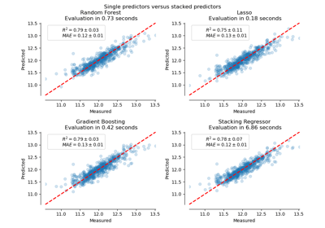

Combine predictors using stacking

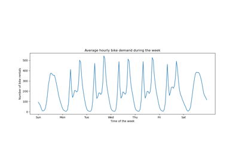

Time-related feature engineering

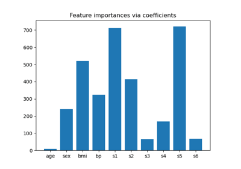

Model-based and sequential feature selection

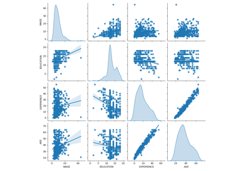

Common pitfalls in the interpretation of coefficients of linear models

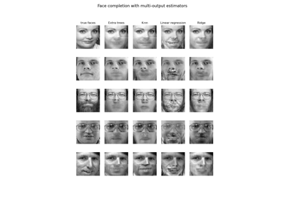

Face completion with a multi-output estimators

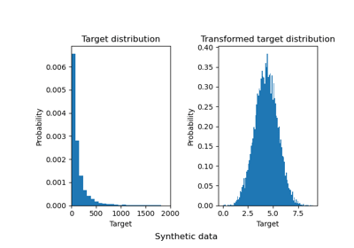

Effect of transforming the targets in regression model

© 2007–2022 The scikit-learn developers  
Licensed under the 3-clause BSD License.  
https://scikit-learn.org/1.1/modules/generated/sklearn.linear_model.RidgeCV.html